# Monte Carlo Simulation - the 2-D Ising Model

Magnetic properties in matter are generally the result of interacting electron spin. Every electron possesses an inherent angular momentum value ("spin") which gives it a magnetic moment. In the presence of an external magnetic field, the electron spins align in one of two directions - this is why electrons are said to have either "up" spin or "down" spin.

Different arrangements of spin have different energy values - in a ferromagnetic material, it is energetically favorable to have the spins aligned.

The central tenet of Statistical Mechanics is that low-energy states are more probable than high-energy states - thus, the spin system will gradually move to an equilibrim state in a stochastic manner. Since it's not a realistic probability to compute the energy of *all* interactions in the system, this problem is an ideal candidate for Monte Carlo simulation. Consider, as [Ising did in 1924](https://en.wikipedia.org/wiki/Ising_model), a simpler model where each spin only interacts with its immediate neighbors. We randomly flip spins, then compute the change in energy of the system - if the flip reduces the energy, then we keep it.

```python
%matplotlib inline
import pandas as pd
import numpy as np
import matplotlib.pyplot as plt
from matplotlib.animation import FuncAnimation
```

# Initialize Spin Lattice

```python
np.random.choice((1, -1), size=(lattice_size, lattice_size))
```

```
array([[-1, -1, -1, -1,  1,  1, -1,  1, -1,  1],
       [ 1,  1, -1,  1,  1,  1,  1,  1, -1, -1],
       [ 1,  1,  1,  1, -1,  1,  1,  1, -1,  1],
       [-1,  1,  1,  1,  1, -1, -1, -1, -1, -1],
       [-1,  1, -1,  1, -1,  1, -1,  1, -1,  1],
       [-1, -1,  1, -1, -1, -1,  1, -1, -1,  1],
       [-1,  1,  1,  1, -1,  1, -1,  1,  1,  1],
       [ 1,  1,  1,  1,  1,  1, -1,  1, -1, -1],
       [-1, -1, -1,  1,  1, -1,  1,  1,  1,  1],
       [-1,  1, -1,  1,  1,  1, -1,  1,  1,  1]])
```

```python
def neighbor_spins(lattice, row, col):
    up = lattice[row-1, col] if row != 0 else lattice[-1, col]
    down = lattice[row+1, col] if row != lattice.shape[0]-1 else lattice[0, col]
    left = lattice[row, col-1] if col != 0 else lattice[row, -1]
    right = lattice[row, col+1] if col != lattice.shape[1]-1 else lattice[row, 0]
    return (up, down, left, right)
```

\begin{equation} \Delta E = Js_i\sum_{j}s_j+hs_i \end{equation}

```python
def one_step(lattice, temperature):
    row = np.random.randint(0, lattice.shape[0])
    col = np.random.randint(0, lattice.shape[1])
    delta_e = lattice[row, col] * np.sum(neighbor_spins(lattice, row, col))
    if delta_e <= 0 or np.exp(-delta_e / temperature) > np.random.uniform():
        lattice[row, col] *= -1
```

```python
def avg_magnetization(lattice):
    return np.sum(lattice) / lattice.size
```

[video not shown]

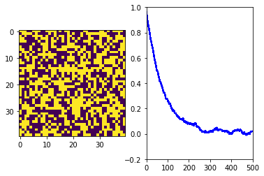

```python
spin_lattice = np.ones(shape=(40, 40), dtype=int)
t = 300
frame_count = 500
one_step(spin_lattice, t)

x = np.arange(frame_count)
y = np.ndarray(frame_count)
y.fill(np.nan)

fig = plt.figure()
ax1 = fig.add_subplot(121)
ax2 = fig.add_subplot(122)
ax2.set_xlim(0, frame_count)
ax2.set_ylim(-0.2, 1)
spins = ax1.imshow(spin_lattice, animated=True)

def update(frame):
    global t, x, y
    for i in range(10):
        one_step(spin_lattice, t)
    y[frame] = avg_magnetization(spin_lattice)
    spins.set_data(spin_lattice)
    ax2.plot(x, y, 'b')
    return spins,

ani = FuncAnimation(fig, update, frames=frame_count, interval=50, blit=True);
HTML(ani.to_html5_video())
```